# Final_report

Minnie, Belle, Kateryna , Jemma, Gracie

2025-10-06

# 1 Introduction

Throughout this project, we explore data relevant to environmental health analysis, focusing on air pollution data from the World Health Organisation. This information can be particularly relevant when identifying areas with high pollutants, trends in pollutant concentrations over time and relationships between pollutants. By exploring this data, we hope to gain an insight into some of these trends, which in a real life scenario could contribute to research in policy making to address these issues. We perform a literature review of resources for helping us analyse our data set, alongside using our own knowledge of EDA and exploring built in R packages. We will walk through how we cleaned and prepared our data, carried out EDA and found ways to visualise different trends we were able to find from this.

## 1.1 The data

Since our data is sourced from the World Health Organisation, we can say with confidence that this data was reliably sourced. The link to our data set can be found: https://www.who.int/publications/m/item/who-ambient-air-quality-database-(update-jan-2024) Our dataset ‘who_data’ can be found found in our report folder.

```r
# Load the data
library(here)
data=read.csv(here("data", "who_data.csv"), stringsAsFactors = FALSE)
```

We removed irrelevant columns from the original, such as “data_source’ and ‘url_links’. We remove these in the processing section.

To begin with, we get an overview of our data using :

```r
head(data)
```

```
##   who_region iso3 country_name         city year  X pm10_concentration
## 1      4_Eur  ESP        Spain A Coruna/ESP 2013 NA             23.238
## 2      4_Eur  ESP        Spain A Coruna/ESP 2014 NA             27.476
## 3      4_Eur  ESP        Spain A Coruna/ESP 2015 NA             25.515
## 4      4_Eur  ESP        Spain A Coruna/ESP 2016 NA             23.057
## 5      4_Eur  ESP        Spain A Coruna/ESP 2017 NA             26.849
## 6      4_Eur  ESP        Spain A Coruna/ESP 2018 NA             27.763
##   pm25_concentration no2_concentration pm10_tempcov pm25_tempcov no2_tempcov
## 1             11.491            28.841           87           46          93
## 2             15.878            19.575           96           88          95
## 3             14.004            22.731           98           71          98
## 4             13.160            20.204           98           98          98
## 5             14.114            21.543           97           97          98
## 6             14.876            20.328           98           86          99
##                   type_of_stations X.1 X.2 population X.3 latitude longitude
## 1           Urban, Urban, Suburban  NA  NA     246146  NA 43.36790 -8.418571
## 2           Urban, Urban, Suburban  NA  NA     247604  NA 43.36803 -8.418233
## 3 Urban, Urban, Suburban, Suburban  NA  NA     247604  NA 43.37038 -8.422900
## 4 Urban, Urban, Suburban, Suburban  NA  NA     247604  NA 43.37038 -8.422900
## 5 Urban, Urban, Suburban, Suburban  NA  NA     247604  NA 43.37038 -8.422900
## 6 Urban, Urban, Suburban, Suburban  NA  NA     247604  NA 43.37038 -8.422900
##   who_ms
## 1      1
## 2      1
## 3      1
## 4      1
## 5      1
## 6      1
```

```r
str(data)
```

```
## 'data.frame':    40388 obs. of  20 variables:
##  $ who_region        : chr  "4_Eur" "4_Eur" "4_Eur" "4_Eur" ...
##  $ iso3              : chr  "ESP" "ESP" "ESP" "ESP" ...
##  $ country_name      : chr  "Spain" "Spain" "Spain" "Spain" ...
##  $ city              : chr  "A Coruna/ESP" "A Coruna/ESP" "A Coruna/ESP" "A Coruna/ESP" ...
##  $ year              : int  2013 2014 2015 2016 2017 2018 2019 2020 2021 2015 ...
##  $ X                 : logi  NA NA NA NA NA NA ...
##  $ pm10_concentration: num  23.2 27.5 25.5 23.1 26.8 ...
##  $ pm25_concentration: num  11.5 15.9 14 13.2 14.1 ...
##  $ no2_concentration : num  28.8 19.6 22.7 20.2 21.5 ...
##  $ pm10_tempcov      : int  87 96 98 98 97 98 98 99 99 NA ...
##  $ pm25_tempcov      : int  46 88 71 98 97 86 95 98 98 100 ...
##  $ no2_tempcov       : int  93 95 98 98 98 99 98 99 99 NA ...
##  $ type_of_stations  : chr  "Urban, Urban, Suburban" "Urban, Urban, Suburban" "Urban, Urban, Suburban, Suburban" "Urban, Urban, Suburban, Suburban" ...
##  $ X.1               : logi  NA NA NA NA NA NA ...
##  $ X.2               : logi  NA NA NA NA NA NA ...
##  $ population        : int  246146 247604 247604 247604 247604 247604 247604 247604 247604 NA ...
##  $ X.3               : logi  NA NA NA NA NA NA ...
##  $ latitude          : num  43.4 43.4 43.4 43.4 43.4 ...
##  $ longitude         : num  -8.42 -8.42 -8.42 -8.42 -8.42 ...
##  $ who_ms            : int  1 1 1 1 1 1 1 1 1 1 ...
```

Evidently, some columns are not needed so we can remove these to focus on the key aspects of the dataset. It is always good to start by looking at the summary data to get an overview of our trends and identify issues.

## 1.2 Processing

```r
#We deleted the columns that were irrelevant.
who_data=subset(data,select=-c(X,X.1,X.2,X.3,who_ms))
summary(who_data)
```

```
##   who_region            iso3           country_name           city
##  Length:40388       Length:40388       Length:40388       Length:40388
##  Class :character   Class :character   Class :character   Class :character
##  Mode  :character   Mode  :character   Mode  :character   Mode  :character
##
##
##
##
##       year      pm10_concentration pm25_concentration no2_concentration
##  Min.   :2010   Min.   :  0.73     Min.   :  1.000    Min.   :   0.002
##  1st Qu.:2014   1st Qu.: 16.26     1st Qu.:  8.603    1st Qu.:  10.163
##  Median :2016   Median : 21.34     Median : 12.710    Median :  16.700
##  Mean   :2016   Mean   : 30.02     Mean   : 19.131    Mean   :  18.862
##  3rd Qu.:2019   3rd Qu.: 30.52     3rd Qu.: 23.000    3rd Qu.:  24.912
##  Max.   :2022   Max.   :540.00     Max.   :436.440    Max.   :3670.314
##  NA's   :293    NA's   :11716      NA's   :18658      NA's   :13454
##   pm10_tempcov     pm25_tempcov     no2_tempcov     type_of_stations
##  Min.   :  0.00   Min.   :  0.00   Min.   :  0.00   Length:40388
##  1st Qu.: 90.00   1st Qu.: 86.00   1st Qu.: 92.00   Class :character
##  Median : 96.00   Median : 96.00   Median : 96.00   Mode  :character
##  Mean   : 88.73   Mean   : 84.12   Mean   : 88.09
##  3rd Qu.: 99.00   3rd Qu.: 99.00   3rd Qu.: 98.00
##  Max.   :100.00   Max.   :100.00   Max.   :100.00
##  NA's   :17985    NA's   :23798    NA's   :16986
##    population          latitude        longitude
##  Min.   :       5   Min.   :-53.16   Min.   :-159.366
##  1st Qu.:   53006   1st Qu.: 37.14   1st Qu.:  -1.259
##  Median :  163729   Median : 43.82   Median :  10.513
##  Mean   :  757193   Mean   : 40.02   Mean   :  10.598
##  3rd Qu.:  590032   3rd Qu.: 49.16   3rd Qu.:  23.226
##  Max.   :37393129   Max.   : 69.68   Max.   : 178.450
##  NA's   :17955      NA's   :290      NA's   :290
```

Before any analysis we need make sure that all the variables are in the correct format (e.g., numeric or factor). Some data should be numeric, but it’s not read as numeric by R. So we convert some numeric-like columns stored as character to numeric.

```r
#Replace literal "NA" strings with proper R NA
who_data_NA = who_data[who_data == "NA"] <- NA

#convert numeric-like columns stored as character to numeric
num_cols <- c("pm10_concentration","pm25_concentration","no2_concentration",
              "pm10_tempcov","pm25_tempcov","no2_tempcov","population")
who_data[num_cols] <- lapply(who_data[num_cols], as.numeric) # set the data as numeric

who_data$type_of_stations <- as.character(who_data$type_of_stations)
who_data$who_region <- as.factor(who_data$who_region)
```

Note: Due to the nature of this project we have all processed our data differently, therefore for each section where we might be exploring time series or region we have titled the data set “who_data_‘*’ “, where ’*’ is replaced with what we are exploring.

# 2 About our data

As we can see we have a range of different types of data: - *Numerical:* Population counts and pollutant concentrations, where:

*pm10_concentration* - Annual mean concentration of particulate matter with diameter of 10 μm or less (µg/m3) *pm25_concentration* - Annual mean concentration of particulate matter with diameter of 2.5μm or less (µg/m3) *no2_concentration* - Annual mean concentration of nitrogen dioxide (µg/m3) These are something we will focus on throughout our project.

-*Temporal:* Year 2010-2022. Time is an important variable when exploring long term changes in concentration of pollutants and can help illustrate trends or patterns. -*Categorical:* Country, city, station type - *Spatial:* Longitude and latitude coordinates (could be useful in determining whether parts of the world have a trend in a higher concentration of pollutants.)

### 2.0.1 Initial notes from our summary

Before carryong out our analysis, we first note some initial observations/concerns that we identified from our summary, we may choose to explore these in more depth or address in our data cleaning. Firstly, we notice a very large range for variables such as no2 concentration. We may consider reasons for these spikes, they could be measurement error or extreme pollution events as a consequence of natural disasters. A good approach to deal with the large ranges is to scale the data, for example, using a log transformation, or we could identify some as outliers and cap the values. We also notice a large number of NA values for each category. We could remove missing data and cap values to avoid extreme outliers, but we might not want to dismiss all the missing data as we could accidentally introduce bias.

## 2.1 Library requirements

# 3 Section: Linear regression models

In this first section of our exploratory analysis, we investigate **air pollution levels** across different cities and areas, focusing on the three main pollutants: **PM_2.5**, **PM_10**, and **NO_2**.  
Our goal is to identify key factors associated with air quality and test whether **population size**, **time trends**, and **regional** or **environmental factors** can help explain variation in pollution levels.

There are **three types of Pollution** we are going to model, corresponding to three different types of response variables:

1. **Y_1 = pm25_concentration**
2. **Y_2 = pm10_concentration**
3. **Y_3 = no2_concentration**

Looking at our dataset, some good candidates for **covariates** could be:

- **population** (city size) -numeric, continuous.
- **year** (to capture time effects) - numeric, discrete.
- **type of stations** (urban, suburban , rural) - categorical.
- **Country/region** - categorical ( possibly grouped by WHO region).

## 3.1 Processing the data:

The data contains a lot of missing values **(N/A)**. There are a number of ways to deal with the missing data, and we will explore various methods throughout the project. For section 1, since R cannot handle missing data directly in regression, we choose to remove the missing values all together, by removing any rows containing **N/A** in the relevant columns.

```r
#For this section we use the ending '_lr' (for linear regression) to indicate the data corresponds to data from Section 1
clean_pm25_lr<- na.omit(who_data[, c("pm25_concentration", "population", "year","type_of_stations","who_region")])
clean_pm10_lr <- na.omit(who_data[, c("pm10_concentration", "population", "year", "type_of_stations", "who_region")])
clean_no2_lr <- na.omit(who_data[, c("no2_concentration",  "population", "year", "type_of_stations", "who_region")])
```

Another issue with our dataset is that some observations have multiple labels in the same cell for **type_of_stations**, eg “urban,suburban, suburban”. R would treat each string as a separate “level”, creating hundreds of basically meaningless categories.

So to keep things manageable at this stage, let us begin with only these predictors: - Population - Year

The general linear regression model can be written as:

$$Y_i = \beta_0 + \beta_1 \,\text{Population}_i + \beta_2
\,\text{Year}_i + \varepsilon_i$$

where
$$\varepsilon_i \sim N(0,
\sigma^2)$$
represents the error term.

## 3.2 Initial Model Fitting for PM₂.₅ Concentration

Now the data has been cleaned, it is ready for modelling. We start with response varibable **Y1 = pm25_concentration**:

We fit the following linear regression model; **pm25_concentration** as a function of **Population** and **Year**:

$$\text{PM}_{2.5,i} = \beta_0 + \beta_1 \cdot \text{Population}_i +
\beta_2 \cdot \text{Year}_i + \varepsilon_i,$$

where $\varepsilon_i \sim N(0, \sigma^2)$ is the error term.

```r
pollution_fit_raw <- lm(pm25_concentration ~ population + year ,
                        data = clean_pm25_lr)

# View results of coefficents
summary(pollution_fit_raw)
```

```
##
## Call:
## lm(formula = pm25_concentration ~ population + year, data = clean_pm25_lr)
##
## Residuals:
##     Min      1Q  Median      3Q     Max
## -13.939  -3.715  -1.360   2.776  58.467
##
## Coefficients:
##               Estimate Std. Error t value Pr(>|t|)
## (Intercept)  1.139e+03  6.621e+01  17.209  < 2e-16 ***
## population   2.100e-07  7.226e-08   2.906  0.00367 **
## year        -5.580e-01  3.282e-02 -16.999  < 2e-16 ***
## ---
## Signif. codes:  0 '***' 0.001 '**' 0.01 '*' 0.05 '.' 0.1 ' ' 1
##
## Residual standard error: 6.109 on 4920 degrees of freedom
## Multiple R-squared:  0.0565, Adjusted R-squared:  0.05612
## F-statistic: 147.3 on 2 and 4920 DF,  p-value: < 2.2e-16
```

Thus, we can see that important predictors are missing. Our next step is to try and and tidy up the predictor *type_of_stations* so we can include it in our analysis.

## 3.3 Extending the Model with type_of_station as a Numeric Predictor

To resolve this issue of multiple location types for one city, we need to force each observation into one category. As an attempt to do this, we will quantify station type by giving it a numeric”population density score”, then taking the average if a city has multiple categories.

We could use the following rankings

```r
# Define ranking system
rankings<- c("Urban" = 5, "Traffic" = 4, "Suburban" = 3, "Background" = 2, "Rural" = 1)

# Function to compute average rank per row
get_rank <- function(x) {     #make the function
  if (is.na(x)) return(NA)
  types <- strsplit(x, ",")[[1]] # splits the text x into seperate pieces
  types <- trimws(types)  # remove spaces
  mean(rankings[types], na.rm = TRUE)
}
```

Note: We found the strsplit() function when researching best approaches to do this , using https://www.geeksforgeeks.org/r-language/strsplit-function-in-r/.

Then we apply this to our data set and fit the following extended linear regression model including a numeric ranking for station type:

$$\text{PM}_{2.5,i} = \beta_0 + \beta_1 \cdot \text{Population}_i +
\beta_2 \cdot \text{Year}_i + \beta_3 \cdot \text{StationRank}_i +
\varepsilon_i,$$

where $\varepsilon_i \sim N(0,\sigma^2)$.

```r
#apply ranking
clean_pm25_lr$station_rank <- sapply(clean_pm25_lr$type_of_stations, get_rank)

# Fit model with numeric rank
fit_type <- lm(pm25_concentration ~ population + year + station_rank, data = clean_pm25_lr)
summary(fit_type)
```

```
##
## Call:
## lm(formula = pm25_concentration ~ population + year + station_rank,
##     data = clean_pm25_lr)
##
## Residuals:
##     Min      1Q  Median      3Q     Max
## -12.909  -3.785  -1.316   2.821  58.354
##
## Coefficients:
##                Estimate Std. Error t value Pr(>|t|)
## (Intercept)   1.159e+03  6.608e+01  17.539  < 2e-16 ***
## population    1.724e-07  7.212e-08   2.390   0.0169 *
## year         -5.692e-01  3.277e-02 -17.371  < 2e-16 ***
## station_rank  6.952e-01  9.377e-02   7.414 1.44e-13 ***
## ---
## Signif. codes:  0 '***' 0.001 '**' 0.01 '*' 0.05 '.' 0.1 ' ' 1
##
## Residual standard error: 6.075 on 4862 degrees of freedom
##   (57 observations deleted due to missingness)
## Multiple R-squared:  0.06789,    Adjusted R-squared:  0.06732
## F-statistic:   118 on 3 and 4862 DF,  p-value: < 2.2e-16
```

Although this extended model preforms better, it still leaves much of the variation unexplained. Up to this point, our predictors, **population**, **year**, and **station rank** ,have all been continuous variables.  
However, air pollution is also strongly influenced by **geography and regional policy differences**, which are not captured by numeric predictors alone.

To account for this, we now introduce **regional and country-level effects** into the model.

## 3.4 Extending the Model with Who_region

Pollution levels could be heavily shaped by **geography and policy**, so adding a factor for country or region will likely explain more variation.

In terms of the linear model, this means adding **categorical (factor) variables** that represent different world regions.  
Each region is encoded using dummy variables, allowing the model to estimate a separate intercept for each group.  
This remains a **linear model**, but one that can capture differences in baseline pollution levels across regions.

The extended linear regression model can be written as:

$$\text{PM}_{2.5,i} = \beta_0 + \beta_1 \cdot \text{Population}_i +
\beta_2 \cdot \text{Year}_i + \beta_3 \cdot \text{StationRank}_i +
\sum_{k=1}^{K-1} \gamma_k \cdot \text{Region}_{k,i} + \varepsilon_i,$$

where $\varepsilon_i \sim N(0, \sigma^2)$ represents the error term, and each $\gamma_k$ measures the difference in average pollution between region *k* and the baseline region.

From our dataset we have the following standard **WHO regional groupings**:

- **AFR** = Africa
- **AMR** = Region of the Americas
- **SEAR** = South- East Asia Region
- **EUR** = European Region
- **EMR** = Eastern Mediterranean
- **WPR** = Western Pacific Regiom
- **NonMS** = Non-Member States ( countries not in WHO, often small territories)

```r
fit_region <- lm(pm25_concentration ~population + year + station_rank + who_region,
                 data = clean_pm25_lr)
summary(fit_region)
```

```
##
## Call:
## lm(formula = pm25_concentration ~ population + year + station_rank +
##     who_region, data = clean_pm25_lr)
##
## Residuals:
##     Min      1Q  Median      3Q     Max
## -13.034  -3.581  -1.366   2.660  58.262
##
## Coefficients:
##                     Estimate Std. Error t value Pr(>|t|)
## (Intercept)        1.171e+03  6.686e+01  17.506  < 2e-16 ***
## population         1.310e-07  7.310e-08   1.792  0.07314 .
## year              -5.745e-01  3.296e-02 -17.428  < 2e-16 ***
## station_rank       6.011e-01  9.293e-02   6.468 1.09e-10 ***
## who_region2_Amr   -3.948e+00  5.974e+00  -0.661  0.50868
## who_region3_Sear   7.959e+00  6.025e+00   1.321  0.18660
## who_region4_Eur   -4.111e-01  5.961e+00  -0.069  0.94503
## who_region5_Emr    1.931e+01  6.523e+00   2.961  0.00309 **
## who_region6_Wpr   -1.881e-01  6.092e+00  -0.031  0.97536
## who_region7_NonMS  3.046e+00  6.671e+00   0.457  0.64799
## ---
## Signif. codes:  0 '***' 0.001 '**' 0.01 '*' 0.05 '.' 0.1 ' ' 1
##
## Residual standard error: 5.951 on 4856 degrees of freedom
##   (57 observations deleted due to missingness)
## Multiple R-squared:  0.1066, Adjusted R-squared:  0.105
## F-statistic:  64.4 on 9 and 4856 DF,  p-value: < 2.2e-16
```

Including the *WHO_region* as a categorical factor improves the model fit, raising the coefficient of determination from about 7% to 11%. This confirms that geography plays an important role in explaining variation in PM$_{2.5}$ concentrations, beyond population size, year, and station type. In this specification, Africa (AFR) is treated as the baseline region.

Overall, the results suggest that while most regional effects are not statistically distinguishable from Africa, the Eastern Mediterranean Region records significantly higher levels of PM$_{2.5}$ even after accounting for population, year, and station type.

Compared with the baseline model in **2. Initial Model Fitting for PM₂.₅ Concentration**, which included only **population** and **year** and explained about 5% of the variation, the addition of **station_rank** and **WHO_region** has roughly doubled explanatory power to 11%, highlighting the importance of including geographic and contextual factors in the analysis. Although the $R^2$ value is still extremely low, this model provides the best fit among the three tested so far.  
We will therefore use this specification to train the next two response variables, **Y_2 = PM₁₀** and **Y_3 = NO₂**.

## 3.5 Applying the Model to Y_2 = PM_10 Concentration

Next, we apply the same linear model specification used for **PM_2.5** to the **PM_10** data.  
This allows us to assess whether the same predictors — **population**, **year**, **station_rank**, and **WHO_region**, also explain variation in **PM_10** concentrations.

The fitted model is given by:

$$\text{PM}_{10,i} = \beta_0 + \beta_1 \cdot \text{Population}_i + \beta_2
\cdot \text{Year}_i + \beta_3 \cdot \text{StationRank}_i +
\sum_{k=1}^{K-1} \gamma_k \cdot \text{Region}_{k,i} + \varepsilon_i,$$

where $\varepsilon_i \sim N(0, \sigma^2)$.

```r
# Apply the same station ranking system to the PM10 dataset
clean_pm10_lr$station_rank <- sapply(clean_pm10_lr$type_of_stations, get_rank)

# Fit the model using the same predictors as before
fit_pm10 <- lm(pm10_concentration ~ population + year + station_rank + who_region,
               data = clean_pm10_lr)

# Display summary of results
summary(fit_pm10)
```

```
##
## Call:
## lm(formula = pm10_concentration ~ population + year + station_rank +
##     who_region, data = clean_pm10_lr)
##
## Residuals:
##     Min      1Q  Median      3Q     Max
## -42.330  -6.084  -2.211   3.602  74.521
##
## Coefficients:
##                     Estimate Std. Error t value Pr(>|t|)
## (Intercept)        1.005e+03  9.401e+01  10.685  < 2e-16 ***
## population         1.251e-06  1.407e-07   8.891  < 2e-16 ***
## year              -4.757e-01  4.667e-02 -10.192  < 2e-16 ***
## station_rank       1.322e+00  1.345e-01   9.828  < 2e-16 ***
## who_region3_Sear  -1.214e+01  2.022e+00  -6.005 2.02e-09 ***
## who_region4_Eur   -2.793e+01  1.233e+00 -22.657  < 2e-16 ***
## who_region5_Emr    2.033e+01  4.625e+00   4.395 1.13e-05 ***
## who_region6_Wpr   -2.927e+01  1.006e+01  -2.908  0.00365 **
## who_region7_NonMS -3.021e+00  2.672e+00  -1.131  0.25829
## ---
## Signif. codes:  0 '***' 0.001 '**' 0.01 '*' 0.05 '.' 0.1 ' ' 1
##
## Residual standard error: 9.956 on 6406 degrees of freedom
##   (99 observations deleted due to missingness)
## Multiple R-squared:  0.1422, Adjusted R-squared:  0.1412
## F-statistic: 132.8 on 8 and 6406 DF,  p-value: < 2.2e-16
```

These estimated coefficients can be interpreted as follows:

- **Population**:$\hat{\beta}_1 \approx 1.25 \times 10^{-6}$.  
  Each additional person in the population increases PM_10 concentration by about 0.0000013 units. In practical terms, a city with one million more people has roughly 1.25 units higher PM_10.
- **Year**:$\hat{\beta}_2 \approx -0.476$.  
  Holding population constant, PM_10 decreases by about 0.48 units per year, suggesting an overall decline over time.
- **Station Rank**: $\hat{\beta}_3 \approx 1.32$ .  
  Moving up one level in urbanisation (e.g. rural → suburban) increases PM_10 by about 1.3 units, confirming higher pollution in urban areas.
- **Regional effects**: Compared with Africa (baseline), Europe (–27.9), South-East Asia (–12.1), and Western Pacific (–29.3) show significantly lower PM_10 levels, while the Eastern Mediterranean (+20.3) records higher pollution.
- **Model fit**:the coefficient of determination is $R^2 \approx 0.142$.  
  This model explains about 14% of the variation in PM_10 concentrations — higher than what was explained for pm_25, but still indicating that additional factors likely influence air quality.

## 3.6 Applying the model to Y_3 = N0_2 Concentration

Finally, we apply the same linear model specification used for **PM_2.5** and **PM_10** to the **NO_2** data.  
This allows us to test whether the same predictors **population**, **year**, **station rank**, and **WHO region** — also explain variation in **NO₂ concentrations** across cities and regions.

The fitted model is given by:

$$\text{NO}_{2} = \beta_0 + \beta_1 \cdot \text{Population}_i + \beta_2
\cdot \text{Year}_i + \beta_3 \cdot \text{StationRank}_i +
\sum_{k=1}^{K-1} \gamma_k \cdot \text{Region}_{k,i} + \varepsilon_i,$$

where $\varepsilon_i \sim N(0, \sigma^2)$.

```r
# Apply the same station ranking system to the NO2 dataset
clean_no2_lr$station_rank <- sapply(clean_no2_lr$type_of_stations, get_rank)

# Fit the model using the same predictors as before
fit_no2 <- lm(no2_concentration ~ population + year + station_rank + who_region,
              data = clean_no2_lr)

# Display summary of results
summary(fit_no2)
```

```
##
## Call:
## lm(formula = no2_concentration ~ population + year + station_rank +
##     who_region, data = clean_no2_lr)
##
## Residuals:
##     Min      1Q  Median      3Q     Max
## -79.901  -6.100  -1.117   5.111  83.364
##
## Coefficients:
##                     Estimate Std. Error t value Pr(>|t|)
## (Intercept)        1.491e+03  8.420e+01  17.710  < 2e-16 ***
## population         2.679e-06  1.119e-07  23.937  < 2e-16 ***
## year              -7.402e-01  4.172e-02 -17.744  < 2e-16 ***
## station_rank       3.023e+00  1.017e-01  29.711  < 2e-16 ***
## who_region3_Sear   4.889e+00  1.673e+00   2.923  0.00348 **
## who_region4_Eur    1.058e+01  7.069e-01  14.965  < 2e-16 ***
## who_region5_Emr    7.696e+00  3.301e+00   2.331  0.01977 *
## who_region6_Wpr   -3.403e+00  2.446e+00  -1.391  0.16431
## who_region7_NonMS  4.855e+00  2.634e+00   1.843  0.06535 .
## ---
## Signif. codes:  0 '***' 0.001 '**' 0.01 '*' 0.05 '.' 0.1 ' ' 1
##
## Residual standard error: 9.125 on 6828 degrees of freedom
##   (24 observations deleted due to missingness)
## Multiple R-squared:  0.2388, Adjusted R-squared:  0.2379
## F-statistic: 267.7 on 8 and 6828 DF,  p-value: < 2.2e-16
```

These estimated coefficients can be interpreted as follows:

- **Population**:$\hat{\beta}_1 \approx 2.68 \times 10^{-6}$ .  
  Each additional person in the population increases N0_2 concentration by about 0.0000027 units. In practical terms, a city with one million more people has roughly 2.7 units higher N0_2.
- **Year**:$\hat{\beta}_2 \approx -0.740$.  
  Holding population constant, N0_2 decreases by about 0.74 units per year, suggesting a clear downwards trend over time.
- **Station Rank**: $\hat{\beta}_3 \approx 3.02$.  
  Moving up one level in urbanisation (e.g. rural -> suburban -> urban) increases N0_2 by about 3 units, showing that more urban areas experience substantially higher N0_2 pollution.
- **Regional effects**: Compared with Africa (baseline),  
  Europe (+10.6), Eastern Mediterranean (+7.7), and South-East Asia (+4.9) show higher NO₂ levels, while Western Pacific (–3.4) is slightly lower but not statistically significant.
- **Model fit**: The coefficient of determination is $R^2 \approx 0.239$.  
  This model explains about 24% of the variation in NO₂ concentrations — the highest explanatory power among the three models, suggesting that NO₂ levels are more strongly linked to population size, urbanisation, and regional context.

# 4 Section: Population size

Throughout this section we will explore the population variable and the impact it has on others. We will look at: - how does air quality change as population increases - are different pollutants different in different pop sizes.- in diff pop brackets what is the average con for each pollutant.

## 4.1 Cleaning the Dataset

For section 2, we took a different approach to cleaning the variables- we cleaned the data set for each column: pm10_concentration, pm25_concentration, no2_concentration, population as well as all of these at once since when we do this we will have less data points to analyse - this will be something to think about later: do we clean the whole data or just for specific columns?

Note: we have used the ‘pop’ suffix to indicate this applies to data for Section 2.

```r
# cleaning the data for specific columns and making the values numbers instead of characters which they currently are.
clean_data_pm10 <-who_data[!is.na(who_data$pm10_concentration), ] %>%
  mutate(across(c(no2_concentration, pm25_concentration, pm10_concentration, population),
                as.numeric))
clean_data_pm25<- who_data[!is.na(who_data$pm25_concentration), ] %>%
  mutate(across(c(no2_concentration, pm25_concentration, pm10_concentration, population),
                as.numeric))
clean_data_no2 <- who_data[!is.na(who_data$no2_concentration), ] %>%
  mutate(across(c(no2_concentration, pm25_concentration, pm10_concentration, population),
                as.numeric))
clean_data_pop <- who_data[!is.na(who_data$population), ] %>%
  mutate(across(c(no2_concentration, pm25_concentration, pm10_concentration, population),
                as.numeric))
# cleaning every column we are using
clean_data_all_pop <- who_data[
  !is.na(who_data$population) &
  !is.na(who_data$no2_concentration) &
  !is.na(who_data$pm25_concentration) &
  !is.na(who_data$pm10_concentration),
] %>%
  mutate(across(c(no2_concentration, pm25_concentration, pm10_concentration, population),
                as.numeric))

# lets also clean the data for one concentration and population so we will have more data points when we visualise the data in the graph

clean_data_pm10_pop <- who_data[
  !is.na(who_data$population) &
  !is.na(who_data$pm10_concentration),
] %>%
  mutate(across(c(no2_concentration, pm25_concentration, pm10_concentration, population),
                as.numeric))

clean_data_pm25_pop <-who_data[
  !is.na(who_data$population) &
  !is.na(who_data$pm25_concentration),
] %>%
  mutate(across(c(no2_concentration, pm25_concentration, pm10_concentration, population),
                as.numeric))

clean_data_no2_pop <- who_data[
  !is.na(who_data$population) &
  !is.na(who_data$no2_concentration),
] %>%
  mutate(across(c(no2_concentration, pm25_concentration, pm10_concentration, population),
                as.numeric))
```

```r
summary(clean_data_all_pop$population)
```

```
##     Min.  1st Qu.   Median     Mean  3rd Qu.     Max.
##       53    97848   237565   957878   703790 30290936
```

To see how the concentration of pollutants changes for different populations we turn the population into a categorical variable making different population brackets. We have set the population brackets below based on the spread of the population provided by the summary above.

## 4.2 Categorical variables

```r
dataset_popbrackets <- clean_data_all_pop %>%
  mutate(pop_bracket = case_when( # create categorical groups, create a new column pop_bracket which assigns the population into the categorical sections
    population < 100000 ~ "<100K",
    population < 250000 ~ "100K–250K",
    population < 1000000 ~ "250K–1M",
    population < 5000000 ~ "1M–5M",
    TRUE ~ ">5M"
  ))
```

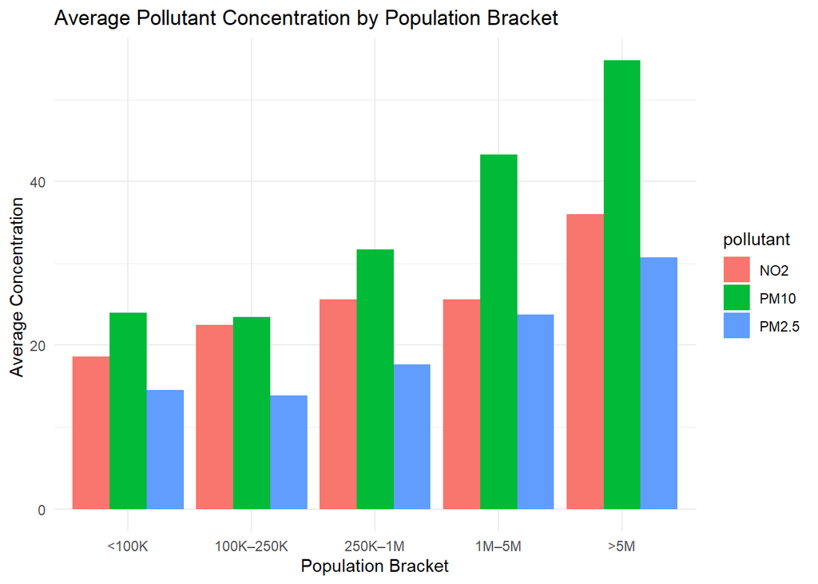

```r
avg_con <- dataset_popbrackets %>%
  group_by(pop_bracket) %>%
  summarise(
    mean_pm25 = mean(pm25_concentration, na.rm = TRUE), # will calculate for each pop bracket
    mean_pm10 = mean(pm10_concentration, na.rm = TRUE),
    mean_no2 = mean(no2_concentration, na.rm = TRUE)
  )

avg_con_long <- avg_con %>%
  pivot_longer(cols = starts_with("mean_"), # changing data format
               names_to = "pollutant",
               values_to = "avg_concentration") %>%
  mutate(pollutant = recode(pollutant,
                            "mean_pm25" = "PM2.5",
                            "mean_pm10" = "PM10",
                            "mean_no2" = "NO2"),
         pop_bracket = factor(pop_bracket,
                              levels = c("<100K", "100K–250K", "250K–1M", "1M–5M", ">5M"))) #orders the x-axis numerically


ggplot(avg_con_long, aes(x = pop_bracket, y = avg_concentration, fill = pollutant)) +
  geom_col(position = "dodge") +
  labs(title = "Average Pollutant Concentration by Population Bracket",
       x = "Population Bracket",
       y = "Average Concentration ",
       fill = "pollutant") +
  theme_minimal()
```

## 4.3 Population vs Concentration Visulisation

Lets use the fully cleaned data.

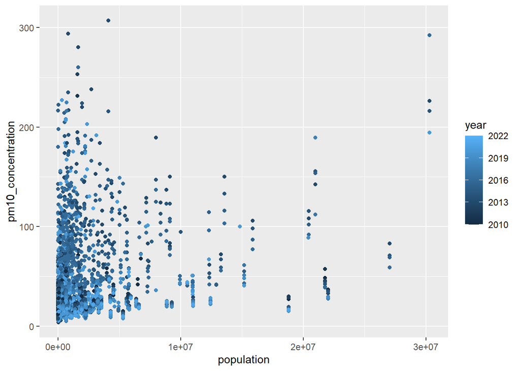

```r
ggplot(data=clean_data_all_pop, aes(x = population, y = pm10_concentration, colour = year)) + geom_point()
```

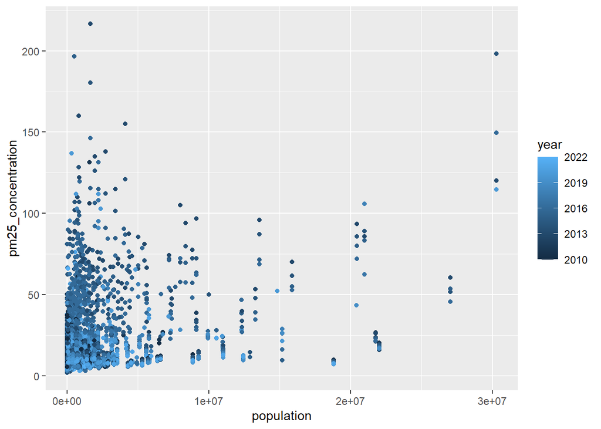

```r
ggplot(data=clean_data_all_pop, aes(x = population, y = pm25_concentration, colour = year)) + geom_point()
```

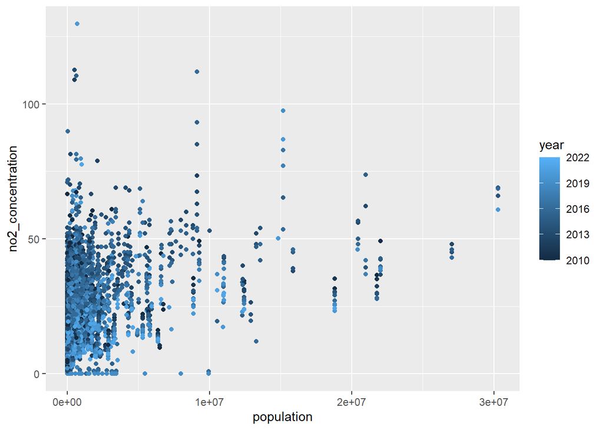

```r
ggplot(data =clean_data_all_pop, aes(x = population, y = no2_concentration, colour = year)) + geom_point()
```

We can’t really see much of a trend here. This might be because we have such a spread in the size of the populations, perhaps by transforming, e.g. taking the log of the population, this will help us see the trend.

## 4.4 Transformed data

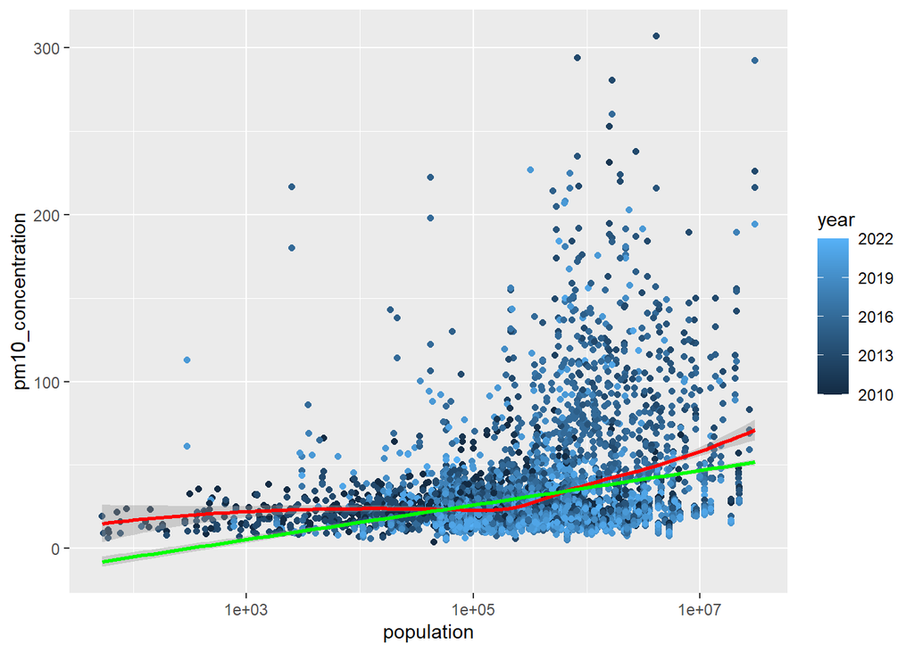

```r
ggplot(data=clean_data_all_pop, aes(x = population, y = pm10_concentration, colour = year)) + geom_point() + scale_x_log10() + geom_smooth(method = 'loess', color = 'red') + geom_smooth(method = 'lm', color = 'green')
```

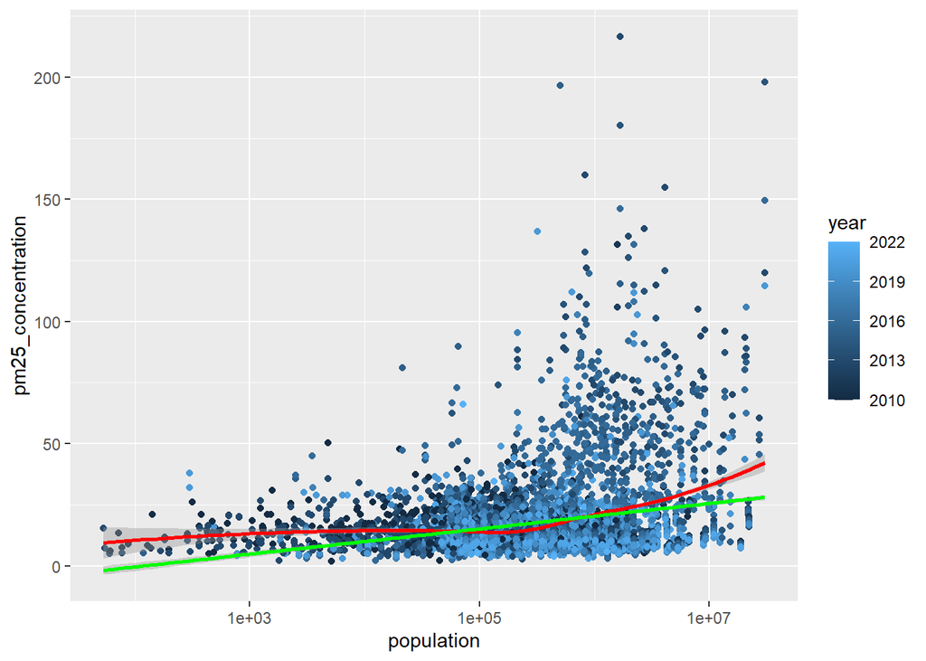

```r
ggplot(data=clean_data_all_pop, aes(x = population, y = pm25_concentration, colour = year)) + geom_point() + scale_x_log10() + geom_smooth(method = 'loess', color = 'red') + geom_smooth(method = 'lm', color = 'green')
```

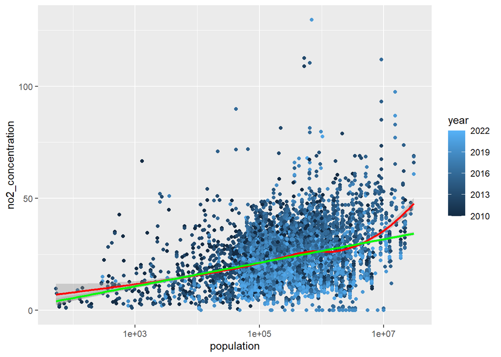

```r
ggplot(data =clean_data_all_pop, aes(x = population, y = no2_concentration, colour = year)) + geom_point() + scale_x_log10() + geom_smooth(method = 'loess', color = 'red') + geom_smooth(method = 'lm', color = 'green')
```

Now we can see a trend in the data- for all the pollutants as the population size increases the concentration increases. This is something we would have expected as a higher population would mean more waste and pollution and hence worse air quality. We have also fit a straight linear line (green) and a loess line (red) which fits a smooth flexible curve to the model in order to highlight the general trend of the plots.

## 4.5 Comparing models

We now compare the two models from the above graphs (linear model and the log transformed model) to determine statistically which model is best

```r
# Linear model - same as above
model1 <- lm(pm25_concentration ~ population, data = clean_data_all_pop)

# Log-transformed model
model_log <- lm(pm25_concentration ~ log10(population), data = clean_data_all_pop)

summary(model1)
```

```
##
## Call:
## lm(formula = pm25_concentration ~ population, data = clean_data_all_pop)
##
## Residuals:
##     Min      1Q  Median      3Q     Max
## -40.717  -7.257  -3.526   2.064 198.107
##
## Coefficients:
##              Estimate Std. Error t value Pr(>|t|)
## (Intercept) 1.567e+01  1.937e-01   80.87   <2e-16 ***
## population  1.710e-06  7.396e-08   23.13   <2e-16 ***
## ---
## Signif. codes:  0 '***' 0.001 '**' 0.01 '*' 0.05 '.' 0.1 ' ' 1
##
## Residual standard error: 15 on 6925 degrees of freedom
## Multiple R-squared:  0.07169,    Adjusted R-squared:  0.07156
## F-statistic: 534.8 on 1 and 6925 DF,  p-value: < 2.2e-16
```

```r
summary(model_log)
```

```
##
## Call:
## lm(formula = pm25_concentration ~ log10(population), data = clean_data_all_pop)
##
## Residuals:
##     Min      1Q  Median      3Q     Max
## -19.886  -7.860  -3.560   2.817 195.090
##
## Coefficients:
##                   Estimate Std. Error t value Pr(>|t|)
## (Intercept)        -10.775      1.337  -8.057 9.12e-16 ***
## log10(population)    5.193      0.245  21.191  < 2e-16 ***
## ---
## Signif. codes:  0 '***' 0.001 '**' 0.01 '*' 0.05 '.' 0.1 ' ' 1
##
## Residual standard error: 15.09 on 6925 degrees of freedom
## Multiple R-squared:  0.0609, Adjusted R-squared:  0.06076
## F-statistic: 449.1 on 1 and 6925 DF,  p-value: < 2.2e-16
```

Here R^2 is lower for the log model which suggests its actually a worse model which is the opposite of what we thought when looking at the graphs.

For the next two models:

```r
# Linear model- same as above
model2 <- lm(pm10_concentration ~ population, data = clean_data_all_pop)

# Log-transformed model
model2_log <- lm(pm10_concentration ~ log10(population), data = clean_data_all_pop)

summary(model2)
```

```
##
## Call:
## lm(formula = pm10_concentration ~ population, data = clean_data_all_pop)
##
## Residuals:
##     Min      1Q  Median      3Q     Max
## -70.202 -11.742  -6.787   1.140 267.005
##
## Coefficients:
##              Estimate Std. Error t value Pr(>|t|)
## (Intercept) 2.730e+01  3.407e-01   80.15   <2e-16 ***
## population  3.084e-06  1.301e-07   23.71   <2e-16 ***
## ---
## Signif. codes:  0 '***' 0.001 '**' 0.01 '*' 0.05 '.' 0.1 ' ' 1
##
## Residual standard error: 26.39 on 6925 degrees of freedom
## Multiple R-squared:  0.07509,    Adjusted R-squared:  0.07495
## F-statistic: 562.2 on 1 and 6925 DF,  p-value: < 2.2e-16
```

```r
summary(model2_log)
```

```
##
## Call:
## lm(formula = pm10_concentration ~ log10(population), data = clean_data_all_pop)
##
## Residuals:
##     Min      1Q  Median      3Q     Max
## -36.313 -12.860  -6.394   2.967 264.244
##
## Coefficients:
##                   Estimate Std. Error t value Pr(>|t|)
## (Intercept)       -25.7413     2.3349  -11.03   <2e-16 ***
## log10(population)  10.3560     0.4278   24.21   <2e-16 ***
## ---
## Signif. codes:  0 '***' 0.001 '**' 0.01 '*' 0.05 '.' 0.1 ' ' 1
##
## Residual standard error: 26.35 on 6925 degrees of freedom
## Multiple R-squared:  0.07802,    Adjusted R-squared:  0.07789
## F-statistic:   586 on 1 and 6925 DF,  p-value: < 2.2e-16
```

```r
# Linear model - same as above
model3 <- lm(no2_concentration ~ population, data = clean_data_all_pop)

# Log-transformed model
model3_log <- lm(no2_concentration ~ log10(population), data = clean_data_all_pop)

summary(model3)
```

```
##
## Call:
## lm(formula = no2_concentration ~ population, data = clean_data_all_pop)
##
## Residuals:
##     Min      1Q  Median      3Q     Max
## -34.894  -7.732  -0.887   6.559 106.558
##
## Coefficients:
##              Estimate Std. Error t value Pr(>|t|)
## (Intercept) 2.219e+01  1.480e-01  149.90   <2e-16 ***
## population  1.278e-06  5.653e-08   22.61   <2e-16 ***
## ---
## Signif. codes:  0 '***' 0.001 '**' 0.01 '*' 0.05 '.' 0.1 ' ' 1
##
## Residual standard error: 11.47 on 6925 degrees of freedom
## Multiple R-squared:  0.06875,    Adjusted R-squared:  0.06861
## F-statistic: 511.2 on 1 and 6925 DF,  p-value: < 2.2e-16
```

```r
summary(model3_log)
```

```
##
## Call:
## lm(formula = no2_concentration ~ log10(population), data = clean_data_all_pop)
##
## Residuals:
##     Min      1Q  Median      3Q     Max
## -31.732  -7.194  -0.807   6.300 103.948
##
## Coefficients:
##                   Estimate Std. Error t value Pr(>|t|)
## (Intercept)        -4.9615     0.9953  -4.985 6.34e-07 ***
## log10(population)   5.2479     0.1824  28.779  < 2e-16 ***
## ---
## Signif. codes:  0 '***' 0.001 '**' 0.01 '*' 0.05 '.' 0.1 ' ' 1
##
## Residual standard error: 11.23 on 6925 degrees of freedom
## Multiple R-squared:  0.1068, Adjusted R-squared:  0.1067
## F-statistic: 828.2 on 1 and 6925 DF,  p-value: < 2.2e-16
```

For NO2 concentration and pm10 concentration the R^2 is higher for the log model suggesting the log relationship is a better model, this is what we expected from looking at the two different graphs.

# 5 Section: Time series and NA analysis

In this section we explore how the concentration changes over time for each country. The aim of this exploration was to identify trends that we would potentially be able to use for further analysis. We also focus on the missing values and explore the trends in missing data.

## 5.1 Dealing with missing data

Evidently missing data creates some issues, but ths can be treated as a point of exploration. We explore to see if there is a trend in missing data, e.g. one country has more missing data than another, to do so we identify *How many NA’s in pm10, pm25 and no2 for each country?* This way we can decide which countries to focus on for our analysis. We begin by exploring the NA counts for pm10. After looking at the summary for the data, we have decided to look at countries that have over 500 data entries and of these, less than 30% of them are NAs.

```r
library(dplyr)
who_data %>%
  group_by(country_name) %>%
  summarise(
    na_count = sum(is.na(pm10_concentration)),
    count= n(),
    proportion=na_count/count) %>%
  filter(proportion< 0.3 & count>500)
```

```
## # A tibble: 12 × 4
##    country_name na_count count proportion
##    <chr>           <int> <int>      <dbl>
##  1 Austria           225  1207     0.186
##  2 Belgium           165   560     0.295
##  3 Czechia            49   956     0.0513
##  4 France            542  3132     0.173
##  5 Germany           559  3266     0.171
##  6 India              37  1301     0.0284
##  7 Italy             523  4035     0.130
##  8 Poland            144  1704     0.0845
##  9 Romania           163   822     0.198
## 10 Spain             552  3343     0.165
## 11 Switzerland        80  1005     0.0796
## 12 T?�rkiye           53  1039     0.0510
```

Now for pm25, we’ve used a lower threshold of over 100 data entries as we have less data collected.

```r
library(dplyr)
who_data %>%
  group_by(country_name) %>%
  summarise(
    na_count = sum(is.na(pm25_concentration)),
    count= n(),
    proportion=na_count/count) %>%
  filter(proportion< 0.3 & count>100)
```

```
## # A tibble: 8 × 4
##   country_name             na_count count proportion
##   <chr>                       <int> <int>      <dbl>
## 1 Australia                      66   221   0.299
## 2 Canada                         77  1169   0.0659
## 3 Chile                          25   210   0.119
## 4 China                           1  3882   0.000258
## 5 Norway                         55   250   0.22
## 6 Slovakia                       31   303   0.102
## 7 South Africa                   46   157   0.293
## 8 United States of America      532  3888   0.137
```

And for no2 we use the same threshold as we did for pm10:

```r
library(dplyr)
who_data %>%
  group_by(country_name) %>%
  summarise(
    na_count = sum(is.na(no2_concentration)),
    count= n(),
    proportion=na_count/count) %>%
  filter(proportion< 0.3 & count>500)
```

```
## # A tibble: 10 × 4
##    country_name                                        na_count count proportion
##    <chr>                                                  <int> <int>      <dbl>
##  1 Austria                                                   77  1207     0.0638
##  2 Belgium                                                   60   560     0.107
##  3 France                                                   454  3132     0.145
##  4 Germany                                                  155  3266     0.0475
##  5 Israel                                                   148   522     0.284
##  6 Italy                                                    183  4035     0.0454
##  7 Spain                                                    280  3343     0.0838
##  8 Sweden                                                   100   601     0.166
##  9 Switzerland                                               48  1005     0.0478
## 10 United Kingdom of Great Britain and Northern Irela…       43   881     0.0488
```

Using this information regarding missing values, we want to use the top 10 most relevant countries, or rather the countries with the highest proportion of usable data in our analysis. For the pm10 analysis we had to decide between what was more important, having a higher count rate but smaller proportion, or having less missing values with less data. We concluded that having more data would be significant in representing each country.

## 5.2 Creating subsets based on missing data

```r
pm10_top_10= who_data %>%
  filter(country_name %in%
c("Austria","Belgium", "Bulgaria", "Czechia","France","Germany","Italy","Netherlands (Kingdom of the)", "Poland","Switzerland"))
pm25_top_10= who_data %>%
  filter(country_name %in% c("Australia","Canada","Chile","China","Norway","Slovakia","South Africa","United States of America"))
no2_top_10= who_data %>%
  filter(country_name %in%
c("Austria","Belgium","France","Germany","Israel","Italy","Spain","Sweden","Switzerland","United Kingdom of Great Britain and Northern Ireland"))

combined_europe= who_data %>%
  filter(country_name %in%
c("Austria","Belgium","France","Bulgaria","Germany","Czechia","Italy","Sweden","United Kingdom of Great Britain and Northern Ireland", "Netherlands (Kingdom of the)", "Poland","Switzerland"))
```

## 5.3 Time series

Now it is time to use this data to explore the relationship between country and particle matter concentrations over time. Below we have created a time series plot for concentrtions of pm10 in Germany.

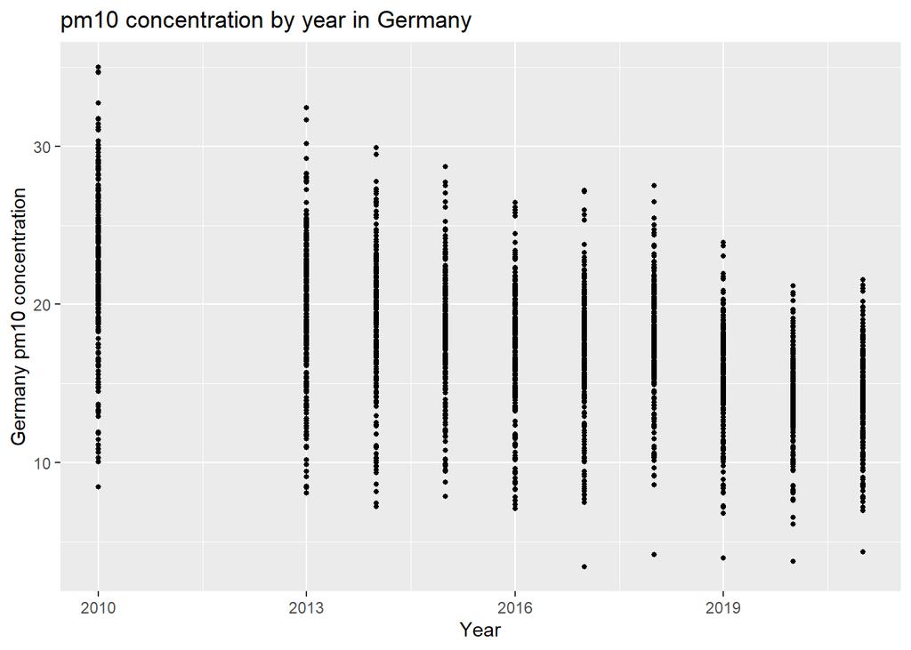

```r
library(ggplot2)
library(dplyr)
germany_data=who_data %>%
  filter(country_name == "Germany")

ggplot(germany_data, aes(x = year, y = pm10_concentration)) +
  geom_point(color ="black", size = 1) +
  labs(
    title = "pm10 concentration by year in Germany",x = "Year",y = "Germany pm10 concentration")
```

Evidently there is a clear trend in Germany’s pm10 concentration over time, if we were to explore this further we could fit a line of best fit to identify at what rate the particle concentration is decreasing over time. Using our subsets we created, we can create time series plots for all of them simultaneously, using facet_wrap. We use ggplot2 as this is a very useful R package for creating data visualisations.

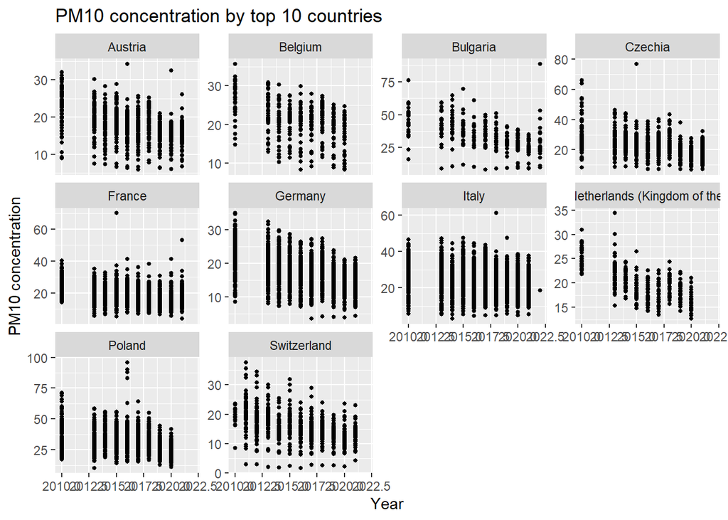

```r
library(ggplot2)
pm10_top_10 %>%
  ggplot(aes(x = year, y = pm10_concentration)) +
  geom_point(color = "black", size = 1) +
  facet_wrap(~ country_name, scales = "free_y") +
  labs(title = "PM10 concentration by top 10 countries",x = "Year",y = "PM10 concentration"
  )
```

[figure not shown]

```r
library(ggplot2)
pm25_top_10 %>%
  ggplot(aes(x = year, y = pm10_concentration)) +
  geom_point(color = "black", size = 1) +
  facet_wrap(~ country_name, scales = "free_y") +
  labs(
    title = "PM25 concentration by top 10 countries",
    x = "Year",
    y = "PM25 concentration"
  )
```

[figure not shown]

```r
library(ggplot2)
no2_top_10 %>%
  ggplot(aes(x = year, y = pm10_concentration)) +
  geom_point(color = "black", size = 1) +
  facet_wrap(~ country_name, scales = "free_y") +
  labs(
    title = "No2 concentration by top 10 countries",
    x = "Year",
    y = "No2 concentration"
  )
```

From this we can see there is a clear downward sloping linear trend in most countries. Interestingly 2011 seems to provide missingdata for most countries, so perhaps we could only focus on years from 2011 onwards in our analysis.

## 5.4 Built in R packages

To further explore the relationshp between time and concentration between country, we decided to explore built in packages in RStudio and see which were relevant to our project. After careful research, we came across the “openair” package, which is particularly relevant to air pollutant data. Carslaw, D. C., & Ropkins, K. (2012). openair — An R package for air quality data analysis. Environmental Modelling & Software, 27–28, 52–61. https://doi.org/10.1016/j.envsoft.2011.09.008

Included in this package is TimePlot, which we decided to use to compare to our scatter plots.

## 5.5 pm10 Time series by country

```r
#install.packages("openair")
library(openair)
library(dplyr)
library(lubridate)
```

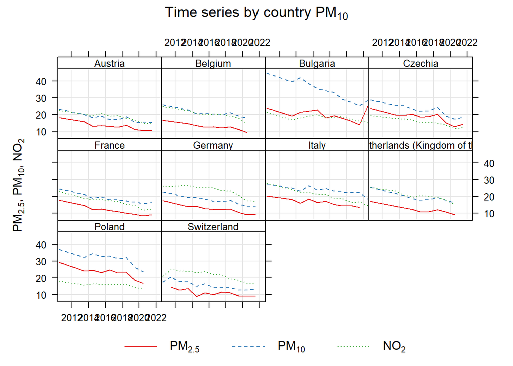

```r
data_openair_country= pm10_top_10 %>%
  filter(!is.na(year)) %>%
  group_by(country_name, year) %>%
  summarise(
    pm25 = mean(pm25_concentration, na.rm = TRUE),
    pm10 = mean(pm10_concentration, na.rm = TRUE),
    no2  = mean(no2_concentration, na.rm = TRUE),
    .groups = "drop"
  ) %>%
  mutate(date = ymd(paste0(year, "-06-30"))) %>%  # because of the nature of this package, we have to generate a date for each year
  select(date, country_name, pm25, pm10, no2)
timePlot(data_openair_country,pollutant = c("pm25", "pm10", "no2"),
         type = "country_name",
         main = "Time series by country pm10")
```

This creates a very clear visualisation of all 3 particle matter types, though the scale is harder to read, I believe these provide a clear insight into the trends, which are obviously negatively correlated.

## 5.6 pm25 Time series by country

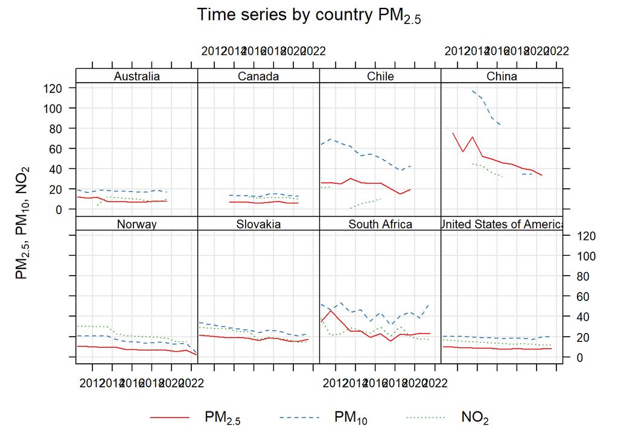

```r
library(openair)
library(dplyr)
library(lubridate)

data_openair_country= pm25_top_10 %>%
  filter(!is.na(year)) %>%
  group_by(country_name, year) %>%
  summarise(
    pm25 = mean(pm25_concentration, na.rm = TRUE),
    pm10 = mean(pm10_concentration, na.rm = TRUE),
    no2  = mean(no2_concentration, na.rm = TRUE),
    .groups = "drop"
  ) %>%
  mutate(date = ymd(paste0(year, "-06-30"))) %>%
  select(date, country_name, pm25, pm10, no2)
timePlot(data_openair_country,
         pollutant = c("pm25", "pm10", "no2"),
         type = "country_name",
         main = "Time series by country pm25")
```

## 5.7 NO2 Time series by country

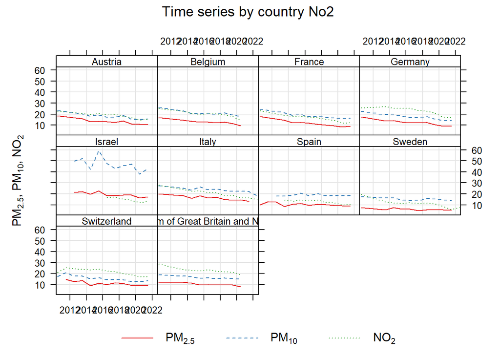

```r
library(openair)
library(dplyr)
library(lubridate)

data_openair_country=no2_top_10 %>%
  filter(!is.na(year)) %>%
  group_by(country_name, year) %>%
  summarise(
    pm25 = mean(pm25_concentration, na.rm = TRUE),
    pm10 = mean(pm10_concentration, na.rm = TRUE),
    no2  = mean(no2_concentration, na.rm = TRUE),
    .groups = "drop"
  ) %>%
  mutate(date = ymd(paste0(year, "-06-30"))) %>%
  select(date, country_name, pm25, pm10, no2)

timePlot(data_openair_country,
         pollutant = c("pm25", "pm10", "no2"),
         type = "country_name",
         main = "Time series by country No2")
```

# 6 Section: Polutant concentration and coverage

For this section of the project, we focus on using the city variable. We : - Explore correlations between PM2.5, PM10, and NO₂.  
- Investigate how data coverage affects these correlations.  
- Explore trends in pollutant levels over time. - Investigate how data coverage affects these trends.

## 6.1 Correlation between PM2.5, PM10, and NO₂

```r
corr_matrix <- cor(who_data[, c("pm25_concentration","pm10_concentration","no2_concentration")],
                   use="complete.obs")
corr_matrix
```

```
##                    pm25_concentration pm10_concentration no2_concentration
## pm25_concentration          1.0000000          0.9070377         0.4489772
## pm10_concentration          0.9070377          1.0000000         0.4427252
## no2_concentration           0.4489772          0.4427252         1.0000000
```

As we can see, PM2.5 and PM10 are strongly positively correlated (0.91). So, cities with higher PM10 usually also have higher PM2.5

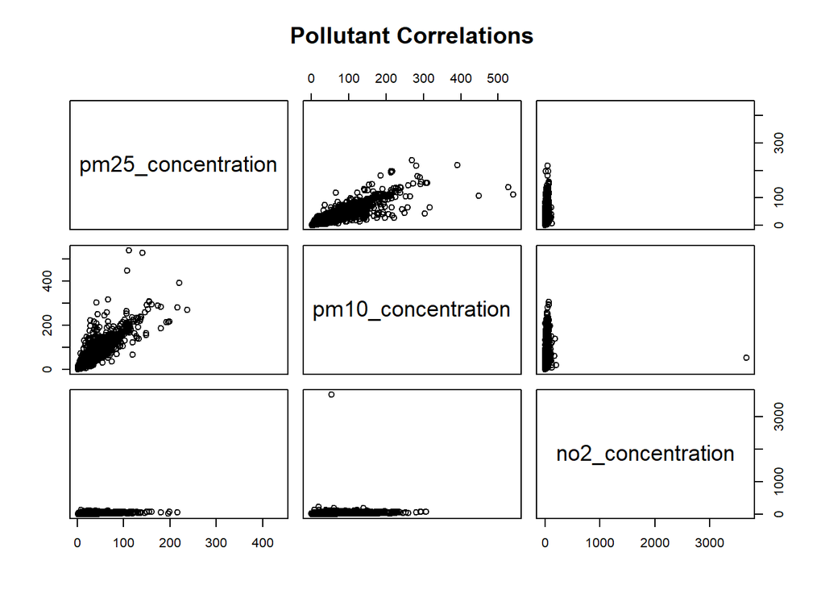

```r
pairs(who_data[, c("pm25_concentration","pm10_concentration","no2_concentration")],
      main="Pollutant Correlations")
```

We look at Temporal Coverage of Pollutants to check how complete the annual monitoring is for each pollutant. To explore this further, we investigate how data coverage affects these correlations.

As we did in Section 3, we explore the coverage of missing data:

```r
# Filter cities with at least 75% coverage
data_highcov <- subset(who_data,
                        pm25_tempcov >= 75 &
                        pm10_tempcov >= 75 &
                        no2_tempcov >= 75)

nrow(data_highcov)  # number of cities remaining
```

```
## [1] 7567
```

```r
# Correlation matrix for high-coverage cities
corr_matrix_highcov <- cor(data_highcov[, c("pm25_concentration",
                                            "pm10_concentration",
                                            "no2_concentration")],
                           use = "complete.obs")
corr_matrix_highcov
```

```
##                    pm25_concentration pm10_concentration no2_concentration
## pm25_concentration          1.0000000          0.8231829         0.4344598
## pm10_concentration          0.8231829          1.0000000         0.4282885
## no2_concentration           0.4344598          0.4282885         1.0000000
```

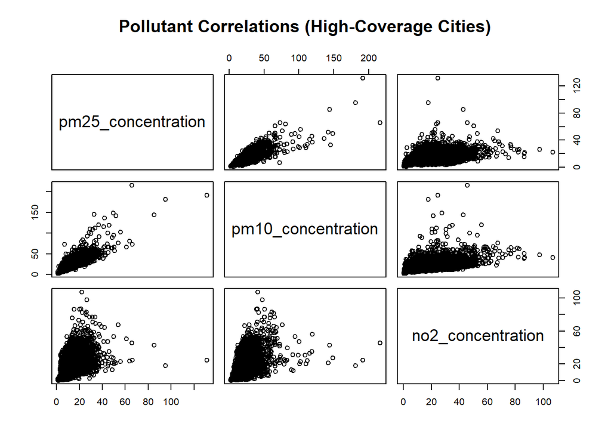

```r
# Scatterplot matrix for high-coverage cities
pairs(data_highcov[, c("pm25_concentration","pm10_concentration","no2_concentration")],
      main="Pollutant Correlations (High-Coverage Cities)")
```

After restricting to cities with at least 75% annual coverage, PM2.5 and PM10 remain strongly positively correlated (r ≈ 0.82). Correlations with NO₂ are moderate (~0.43). The slight reduction in correlation reflects the removal of extreme values, making these estimates more reliable.

## 6.2 Concentration over time by city

We calculate the average concentration per year for PM2.5, PM10, and NO2 using all available data. This shows overall trends in air quality over time and lets us compare pollutants. Averages ignore missing values, so each year reflects the data that’s actually recorded.

```
## Warning: Using `size` aesthetic for lines was deprecated in ggplot2 3.4.0.
## ℹ Please use `linewidth` instead.
## This warning is displayed once every 8 hours.
## Call `lifecycle::last_lifecycle_warnings()` to see where this warning was
## generated.
```

```
## Warning: Removed 1 row containing missing values or values outside the scale range
## (`geom_line()`).
## Removed 1 row containing missing values or values outside the scale range
## (`geom_line()`).
## Removed 1 row containing missing values or values outside the scale range
## (`geom_line()`).
```

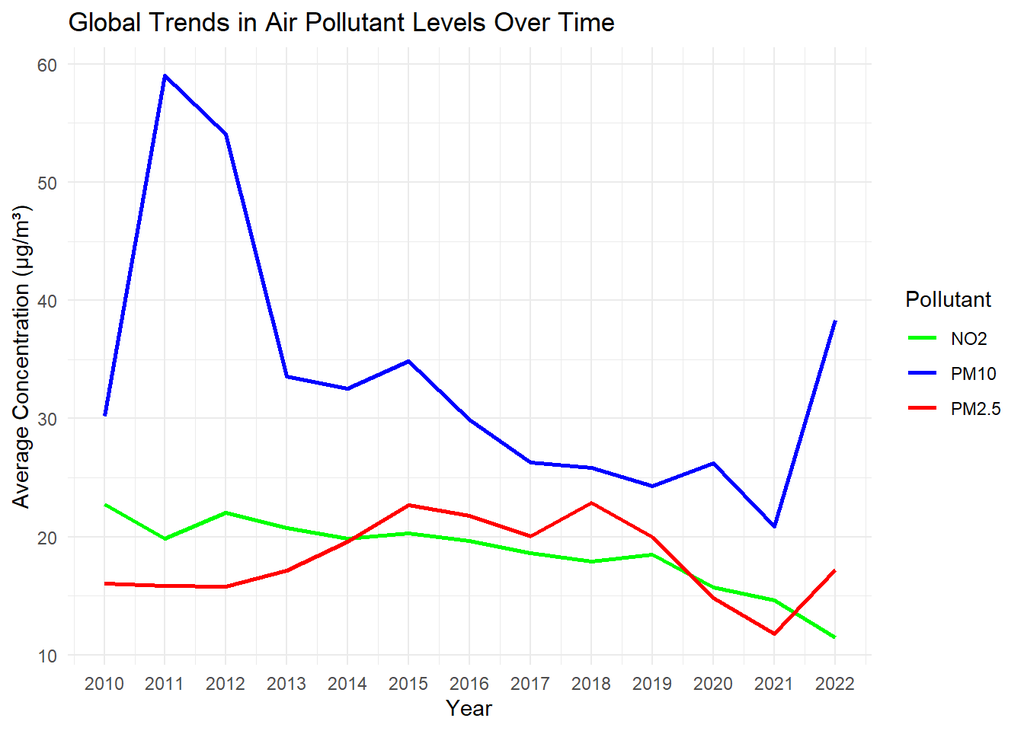

```r
trend_data <- who_data %>%
  group_by(year) %>%
  summarise(mean_pm25 = mean(pm25_concentration, na.rm = TRUE),
            mean_pm10 = mean(pm10_concentration, na.rm = TRUE),
            mean_no2  = mean(no2_concentration, na.rm = TRUE))

ggplot(trend_data, aes(x = as.integer(year))) +
  geom_line(aes(y = mean_pm10, colour = "PM10"), size = 1) +
  geom_line(aes(y = mean_no2,  colour = "NO2"), size = 1) +
  geom_line(aes(y = mean_pm25, colour = "PM2.5"), size = 1) +
  scale_colour_manual(values = c("PM10" = "blue",
                                 "NO2"  = "green",
                                 "PM2.5" = "red")) +
  scale_x_continuous(breaks = unique(trend_data$year)) +
  labs(title = "Global Trends in Air Pollutant Levels Over Time",
       y = "Average Concentration (µg/m³)", x = "Year",
       colour = "Pollutant") +
  theme_minimal()
```

We get some warnings when plotting because a few rows have missing or invalid values for the year or pollutant. There are also noticeable spikes in PM10 for certain years, due to missing data and outliers. For example, some years might have only a few days recorded or only some pollutants measured.

To get a clearer picture, we focus on rows where all three pollutants are recorded. This removes missing values and lets us calculate yearly averages more reliably. Comparing this complete data subset with the full dataset shows whether the overall trends are consistent or affected by missing data.

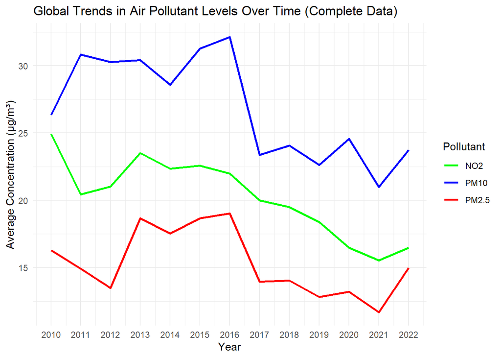

```r
# Trends Over Time (Complete Data )
data_complete <- who_data %>%
  filter(!is.na(pm25_concentration),
         !is.na(pm10_concentration),
         !is.na(no2_concentration))

trend_data_complete <- data_complete %>%
  group_by(year) %>%
  summarise(mean_pm25 = mean(pm25_concentration, na.rm = TRUE),
            mean_pm10 = mean(pm10_concentration, na.rm = TRUE),
            mean_no2  = mean(no2_concentration, na.rm = TRUE))

ggplot(trend_data_complete, aes(x = as.integer(year))) +
  geom_line(aes(y = mean_pm10, colour = "PM10"), size = 1) +
  geom_line(aes(y = mean_no2,  colour = "NO2"), size = 1) +
  geom_line(aes(y = mean_pm25, colour = "PM2.5"), size = 1) +
  scale_colour_manual(values = c("PM10" = "blue",
                                 "NO2"  = "green",
                                 "PM2.5" = "red")) +
  scale_x_continuous(breaks = unique(trend_data_complete$year)) +
  labs(title = "Global Trends in Air Pollutant Levels Over Time (Complete Data)",
       y = "Average Concentration (µg/m³)", x = "Year",
       colour = "Pollutant") +
  theme_minimal()
```

Now all concentrations are between 10 and 35, so the range is smaller. In this filtered data, PM10 is always the highest, followed by NO₂, and then PM2.5. This ordering is clearer because extreme values and missing data have been removed.

```r
# Total rows
n_all <- nrow(data)
n_all
```

```
## [1] 40388
```

```r
# Complete data (all three pollutants recorded)
data_complete <- data[complete.cases(data[, c("pm25_concentration","pm10_concentration","no2_concentration")]), ]
n_complete <- nrow(data_complete)
n_complete
```

```
## [1] 11864
```

```r
# Complete data + high coverage (≥75% for all pollutants)
data_highcov_complete <- data_complete %>%
  filter(!is.na(pm25_tempcov), !is.na(pm10_tempcov), !is.na(no2_tempcov),
         pm25_tempcov >= 75, pm10_tempcov >= 75, no2_tempcov >= 75)

n_highcov_complete <- nrow(data_highcov_complete)
n_highcov_complete
```

```
## [1] 7563
```

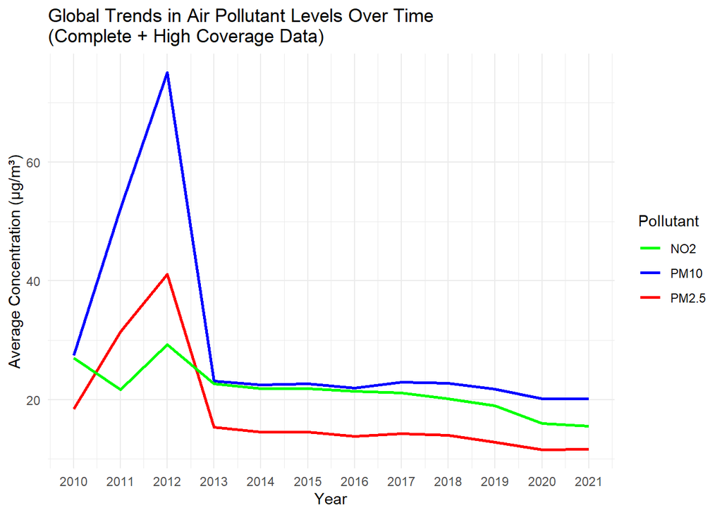

```r
trend_highcov_complete <- data_highcov_complete %>%
  group_by(year) %>%
  summarise(mean_pm25 = mean(pm25_concentration, na.rm = TRUE),
            mean_pm10 = mean(pm10_concentration, na.rm = TRUE),
            mean_no2  = mean(no2_concentration, na.rm = TRUE))

ggplot(trend_highcov_complete, aes(x = as.integer(year))) +
  geom_line(aes(y = mean_pm25, colour = "PM2.5"), size = 1) +
  geom_line(aes(y = mean_pm10, colour = "PM10"), size = 1) +
  geom_line(aes(y = mean_no2,  colour = "NO2"), size = 1) +
  scale_colour_manual(values = c("PM2.5" = "red",
                                 "PM10"  = "blue",
                                 "NO2"   = "green")) +
  scale_x_continuous(breaks = unique(trend_highcov_complete$year)) +
  labs(title = "Global Trends in Air Pollutant Levels Over Time\n(Complete + High Coverage Data)",
       y = "Average Concentration (µg/m³)", x = "Year",
       colour = "Pollutant") +
  theme_minimal()
```

However, for 2010–2013 the pollution shows noticeable spikes, so we need to check how much data we actually have for those years. Filtering for high coverage makes the trends less reliable there. After 2013 the trends are smoother, and we can clearly see that PM10 is always the highest, followed by NO₂, then PM2.5, with all pollutants generally decreasing

```r
summary_table <- data_highcov_complete %>%
  group_by(year) %>%
  summarise(n = n(),
            mean_pm25 = mean(pm25_concentration, na.rm = TRUE),
            mean_pm10 = mean(pm10_concentration, na.rm = TRUE),
            mean_no2  = mean(no2_concentration, na.rm = TRUE)) %>%
  arrange(year)
kable(summary_table,
      digits = 2,
      col.names = c("Year", "Observations", "PM2.5 (µg/m³)", "PM10 (µg/m³)", "NO2 (µg/m³)"),
      caption = "") %>%
  kable_styling(full_width = FALSE, bootstrap_options = c("striped", "hover", "condensed"))
```

| Year | Observations | PM2.5 (µg/m³) | PM10 (µg/m³) | NO2 (µg/m³) |
| --- | --- | --- | --- | --- |
| 2010 | 377 | 18.43 | 27.45 | 27.05 |
| 2011 | 1 | 31.43 | 52.20 | 21.66 |
| 2012 | 2 | 41.14 | 75.11 | 29.24 |
| 2013 | 565 | 15.37 | 23.12 | 22.66 |
| 2014 | 618 | 14.53 | 22.49 | 21.86 |
| 2015 | 707 | 14.50 | 22.71 | 21.87 |
| 2016 | 768 | 13.78 | 21.99 | 21.37 |
| 2017 | 839 | 14.29 | 22.96 | 21.10 |
| 2018 | 892 | 13.97 | 22.78 | 20.10 |
| 2019 | 962 | 12.80 | 21.74 | 18.98 |
| 2020 | 995 | 11.53 | 20.16 | 15.99 |
| 2021 | 837 | 11.66 | 20.11 | 15.57 |

For years 2011 and 2012, there are only 1–2 records available. This makes the average concentrations for those years highly unreliable.

## 6.3 Coverage by region

Now we look at how data coverage is spread across regions. This shows where the high-coverage data comes from, where coverage is low, and where it’s missing. It also helps us see which regions are well represented and which aren’t, so we know the limits of what we can analyse.

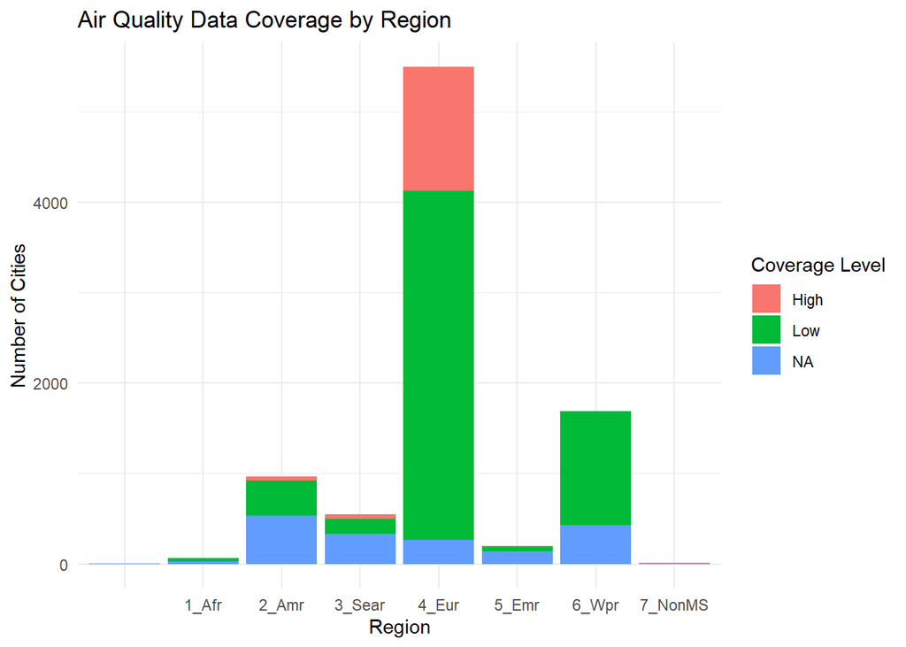

```r
library(dplyr)
library(ggplot2)
#we classify each city by coverage
data_coverage <- who_data %>%
  mutate(
    coverage_category = case_when(
      is.na(pm25_tempcov) & is.na(pm10_tempcov) & is.na(no2_tempcov) ~ "NA",
      pm25_tempcov >= 75 & pm10_tempcov >= 75 & no2_tempcov >= 75 ~ "High",
      TRUE ~ "Low"
    )
  )
coverage_by_region <- data_coverage %>%
  group_by(who_region, coverage_category) %>%
  summarise(n_cities = n_distinct(city), .groups = "drop")

#we now create our plot
ggplot(coverage_by_region, aes(x = who_region, y = n_cities, fill = coverage_category)) +
  geom_bar(stat = "identity") +
  labs(
    title = "Air Quality Data Coverage by Region",
    x = "Region",
    y = "Number of Cities",
    fill = "Coverage Level"
  ) +
  theme_minimal()
```

Most high-coverage cities are in Europe, with some in Southeast Asia and North America. This means the trends from high-coverage data mainly reflect European cities and aren’t representative of global air quality. Regions like Africa and the Eastern Mediterranean have very little data, so we can’t draw any conclusions there.

This section looks explores the dataset grouped the the WHO defined ‘regions’ which are: -Africa -The Americas -South East Asia region -Europe -East Mediterranean region -West Pacific region

```r
numeric_df <- data[sapply(data,is.numeric)]#separating numeric columns
#Separating the data into regions
df_eu <- data[data$who_region=='4_Eur',]
df_amr <- data[data$who_region=='2_Amr',]
summary(df_amr)
```

```
##   who_region            iso3           country_name           city
##  Length:6321        Length:6321        Length:6321        Length:6321
##  Class :character   Class :character   Class :character   Class :character
##  Mode  :character   Mode  :character   Mode  :character   Mode  :character
##
##
##
##
##       year         X           pm10_concentration pm25_concentration
##  Min.   :2010   Mode:logical   Min.   :  3.65     Min.   : 2.000
##  1st Qu.:2013   NA's:6321      1st Qu.: 15.90     1st Qu.: 6.650
##  Median :2016                  Median : 21.60     Median : 8.075
##  Mean   :2016                  Mean   : 27.43     Mean   : 9.585
##  3rd Qu.:2018                  3rd Qu.: 34.00     3rd Qu.: 9.898
##  Max.   :2021                  Max.   :132.19     Max.   :66.646
##                                NA's   :3126       NA's   :1311
##  no2_concentration  pm10_tempcov     pm25_tempcov     no2_tempcov
##  Min.   : 0.008    Min.   :  0.00   Min.   :  0.00   Min.   :  0.00
##  1st Qu.: 8.445    1st Qu.: 71.00   1st Qu.:  1.00   1st Qu.:  1.00
##  Median :13.000    Median : 86.00   Median : 59.00   Median :  1.00
##  Mean   :14.974    Mean   : 73.01   Mean   : 47.58   Mean   : 25.89
##  3rd Qu.:19.412    3rd Qu.: 95.00   3rd Qu.: 96.00   3rd Qu.: 75.00
##  Max.   :82.364    Max.   :100.00   Max.   :100.00   Max.   :100.00
##  NA's   :3509      NA's   :5696     NA's   :4934     NA's   :5261
##  type_of_stations     X.1            X.2            population
##  Length:6321        Mode:logical   Mode:logical   Min.   :      20
##  Class :character   NA's:6321      NA's:6321      1st Qu.:   38431
##  Mode  :character                                 Median :  181697
##                                                   Mean   :  835390
##                                                   3rd Qu.:  664225
##                                                   Max.   :22043028
##                                                   NA's   :809
##    X.3             latitude        longitude           who_ms
##  Mode:logical   Min.   :-53.16   Min.   :-159.37   Min.   :1
##  NA's:6321      1st Qu.: 30.44   1st Qu.:-105.37   1st Qu.:1
##                 Median : 39.02   Median : -85.99   Median :1
##                 Mean   : 30.53   Mean   : -89.51   Mean   :1
##                 3rd Qu.: 43.47   3rd Qu.: -76.70   3rd Qu.:1
##                 Max.   : 68.36   Max.   : -38.31   Max.   :1
##
```

```r
summary(df_eu)
```

```
##   who_region            iso3           country_name           city
##  Length:26801       Length:26801       Length:26801       Length:26801
##  Class :character   Class :character   Class :character   Class :character
##  Mode  :character   Mode  :character   Mode  :character   Mode  :character
##
##
##
##
##       year         X           pm10_concentration pm25_concentration
##  Min.   :2010   Mode:logical   Min.   :  0.73     Min.   : 1.00
##  1st Qu.:2014   NA's:26801     1st Qu.: 15.82     1st Qu.: 9.27
##  Median :2017                  Median : 20.22     Median :12.33
##  Mean   :2016                  Mean   : 22.80     Mean   :13.61
##  3rd Qu.:2019                  3rd Qu.: 26.33     3rd Qu.:16.61
##  Max.   :2022                  Max.   :146.69     Max.   :85.00
##                                NA's   :4520       NA's   :15224
##  no2_concentration   pm10_tempcov     pm25_tempcov     no2_tempcov
##  Min.   :   0.016   Min.   :  0.00   Min.   :  0.00   Min.   :  0.00
##  1st Qu.:  10.456   1st Qu.: 91.00   1st Qu.: 89.00   1st Qu.: 93.00
##  Median :  17.034   Median : 97.00   Median : 96.00   Median : 96.00
##  Mean   :  18.885   Mean   : 90.21   Mean   : 87.43   Mean   : 92.33
##  3rd Qu.:  24.968   3rd Qu.: 99.00   3rd Qu.: 99.00   3rd Qu.: 99.00
##  Max.   :3670.314   Max.   :100.00   Max.   :100.00   Max.   :100.00
##  NA's   :4163       NA's   :5986     NA's   :15770    NA's   :4993
##  type_of_stations     X.1            X.2            population
##  Length:26801       Mode:logical   Mode:logical   Min.   :       6
##  Class :character   NA's:26801     NA's:26801     1st Qu.:   34968
##  Mode  :character                                 Median :   92716
##                                                   Mean   :  258073
##                                                   3rd Qu.:  208159
##                                                   Max.   :15190336
##                                                   NA's   :16451
##    X.3             latitude        longitude          who_ms
##  Mode:logical   Min.   :-21.34   Min.   :-63.08   Min.   :1
##  NA's:26801     1st Qu.: 42.58   1st Qu.:  4.09   1st Qu.:1
##                 Median : 46.82   Median : 10.30   Median :1
##                 Mean   : 46.30   Mean   : 10.58   Mean   :1
##                 3rd Qu.: 50.63   3rd Qu.: 16.68   3rd Qu.:1
##                 Max.   : 69.68   Max.   : 74.58   Max.   :1
##
```

At a first glance comparing two different regions we can see that there are large difference in the quantity of data in, and how much data is missing from each region. Exploring this further we look at the proportion of missing data from each region, for each pollutant.

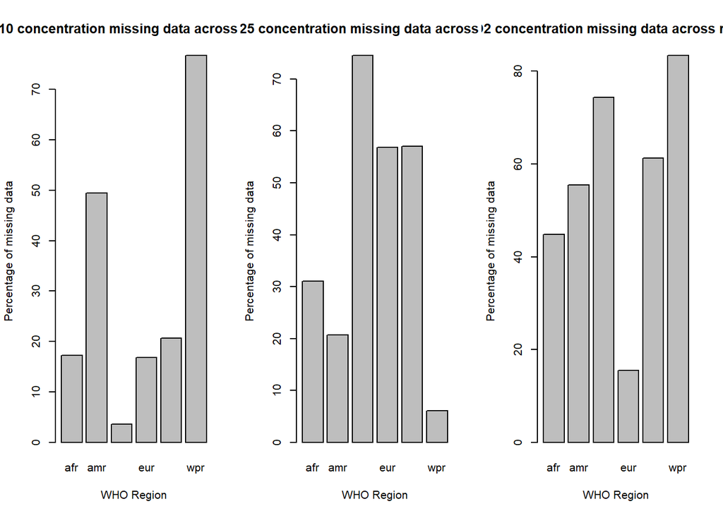

```r
# Count missing values in each column using sapply()
regional_numeric <- numeric_df
regional_numeric$who_region <- data$who_region
afr_nas<- sapply(regional_numeric[regional_numeric$who_region=='1_Afr',], function(x) sum(is.na(x)))
afr_nas <- (afr_nas/nrow(regional_numeric[regional_numeric$who_region=='1_Afr',]))*100

amr_nas <- sapply(regional_numeric[regional_numeric$who_region=='2_Amr',], function(x) sum(is.na(x)))
amr_nas <- (amr_nas/nrow(regional_numeric[regional_numeric$who_region=='2_Amr',]))*100

sear_nas <- sapply(regional_numeric[regional_numeric$who_region=='3_Sear',], function(x) sum(is.na(x)))
sear_nas <- (sear_nas/nrow(regional_numeric[regional_numeric$who_region=='3_Sear',]))*100

eur_nas <- sapply(regional_numeric[regional_numeric$who_region=='4_Eur',], function(x) sum(is.na(x)))
eur_nas <- (eur_nas/nrow(regional_numeric[regional_numeric$who_region=='4_Eur',]))*100

emr_nas <- sapply(regional_numeric[regional_numeric$who_region=='5_Emr',], function(x) sum(is.na(x)))
emr_nas <- (emr_nas/nrow(regional_numeric[regional_numeric$who_region=='5_Emr',]))*100

wpr_nas <- sapply(regional_numeric[regional_numeric$who_region=='6_Wpr',], function(x) sum(is.na(x)))
wpr_nas <- (wpr_nas/nrow(regional_numeric[regional_numeric$who_region=='6_Wpr',]))*100

missing_vals <- data.frame(afr = afr_nas, amr = amr_nas, sear = sear_nas, eur = eur_nas, emr= emr_nas, wpr = wpr_nas)
pm10 <- as.numeric(missing_vals[2,])
pm25 <- as.numeric(missing_vals[3,])
no2 <- as.numeric(missing_vals[4,])


par(mfrow=c(1,3))
#par(pin = c(2,1.5))
barplot(height = pm10, names.arg = colnames(missing_vals), xlab = "WHO Region", ylab = "Percentage of missing data", main = "PM10 concentration missing data across regions")
barplot(height = pm25, names.arg = colnames(missing_vals), xlab = "WHO Region", ylab = "Percentage of missing data", main = "PM25 concentration missing data across regions")
barplot(height = no2, names.arg = colnames(missing_vals), xlab = "WHO Region", ylab = "Percentage of missing data", main = "NO2 concentration missing data across regions")
```

These bar plots show that PM10 concentration is the most consistently recorded pollutant overall, and no single region is well recorded across all three pollutants.

This section continues onto the Jupyter notebook file.